# wrangle_report

## WeRateDogs Wrangling Report.

### Author: Sulaiman Handu

WeRateDogs is a Twitter account that rates people's dogs with humorous comments about the dogs. The wrangling process for this dataset includes:

- Gathering
- Assessing
- Cleaning

## Gathering

There were three different data to be gathered for this report. All three data were imported and merged to create a master dataset that will be used for analysis. Each of the data used had a unique format and had to be imported differently.

1. The first data was manually downloaded from Udacity's website. It was a flat file in a CSV format. The data was then uploaded into the notebook using Panda's read_csv function.
2. The second data was programmatically downloaded using the [URL](https://d17h27t6h515a5.cloudfront.net/topher/2017/August/599fd2ad_image-predictions/image-predictions.tsv) and the requests library to get its contents and then save to a file called "image-predictions.tsv". The panda’s read_csv function is then used to import the data into the notebook.

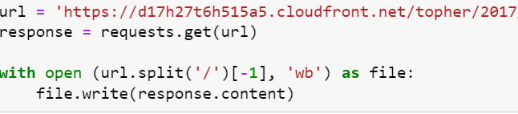

3. The last data was to be extracted from the Twitter API using the tweepy library, But I struggled to get the developer’s account needed for this task. Twitter was unable to complete my verifications. So, I settled for the option of using the extracted data which has been saved as a JSON file. I read the JSON file which has been saved line by line. Then used the for loop to iterate each line extracting the tweet_ids, retweet_counts, favourite_counts. The extract was converted to a dataframe using panda's DataFrame function.

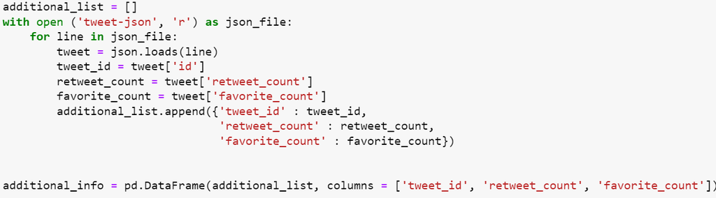

## Assessing

Assessing the data was done both visually and programmatically. This assessment is needed to ensure that issues relating to the tidiness and quality of the data are cleaned to remove potential causes of errors in our analysis or getting insight.

## Cleaning

### For Quality Issues

1. Changing Formats: The function used to change the format of a column is the astype() function.
2. Changing to DataTime format: Changing a data column into the datetime format requires using the panda's to_datetime() function.

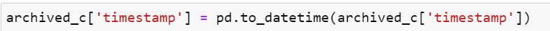

3. Dropping Irrelevant Rows and Columns: This was achieved using the drop() functions.

   > for Unwanted rows, I filtered our datasets and got their indices. Then i passed the index into the drop() function. By default, the axis chosen will be 0 (row).

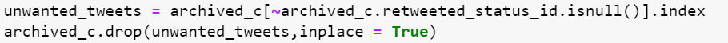

> For Unwanted Columns. A list of column was passed into the drop() function and the axis needed to be specified as 1 (for column).

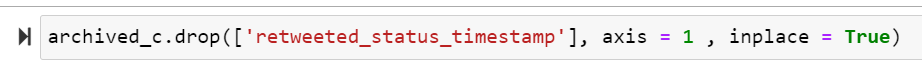

1. For dropping Null Values: Using the dropna() function, I specified an argument to subset the column that will have its null values dropped.
2. Maintaining Consistency in Alphabetic Cases: I wanted the Title cases for all the qualitative data. I used the str.title() function to achieve this.

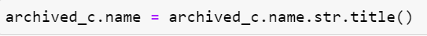

3. Replacing Values: for incorrect values a null value was assigned. In most cases we had the null value not well represented. The cases where i needed to replace values were to many. so, i created a function that takes the column and value as input and assigns a null value as the new value. This was achieved primarily with the replace() function.

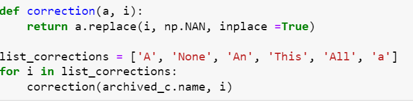

### Tidiness Issues

1. Reshaping Data: Using the panda's melt() function, we reshaped dog stages from multiple columns to a single column.

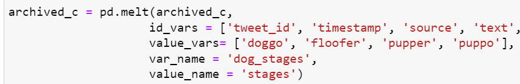

2. Creating A new column: a new column called ratings was created to have the numerator and denominator together.
3. Joining All Tables: An inner Join was performed to merge all the data into a single dataset. This was done using the panda's merge().

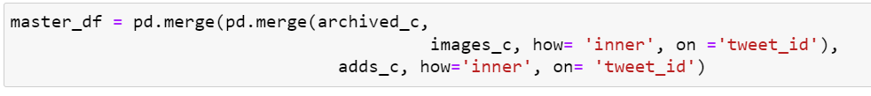

### Storing New Data

After all the wrangling processes, the resulting dataset was stored as CSV file into the file named 'twitter_archive_master.csv'.

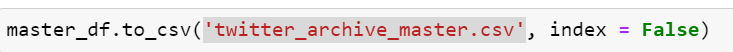